# Project1

# Interpretation: Overall, I do not see much correlation. The points do not follow a trend in any way, including the top 50 points. I do not see any variation between top50 trends and regular plot trends as well. I did notice however that the cme_width and angle is fairly high in Top 50 solar flares

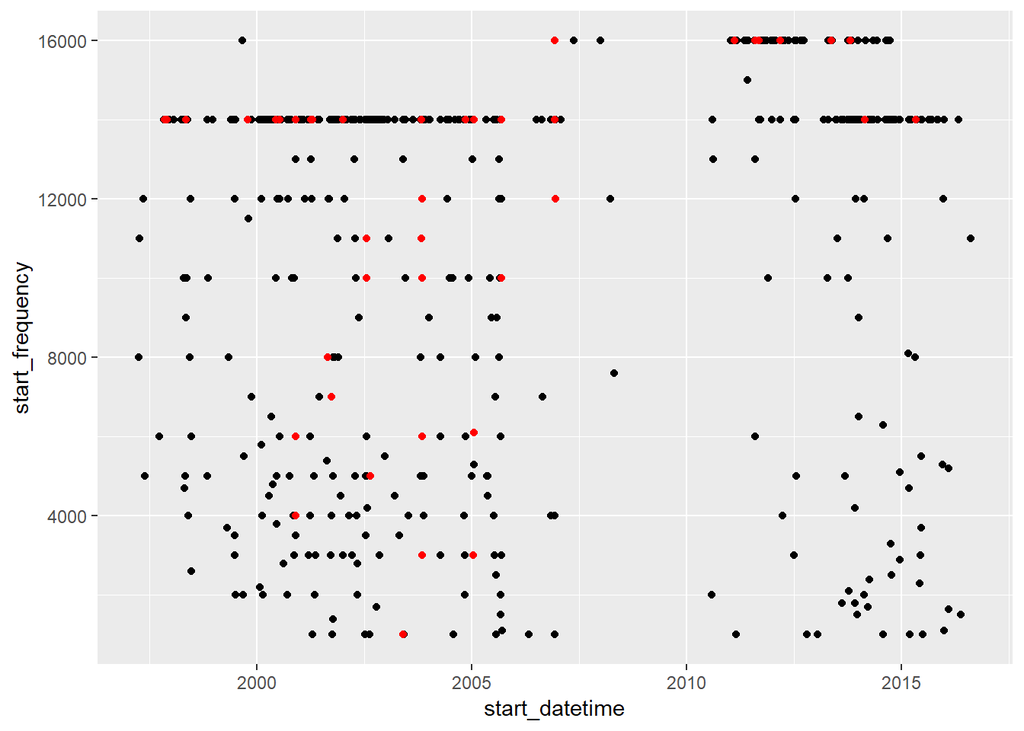

```r
#Start frequency over time plot. Top 50 are highlighted in Red
start_freq_plot <- nasa %>% ggplot(mapping=aes(y=start_frequency, x= start_datetime), na.rm=TRUE) + geom_point() + geom_point(data = nasa_top50, aes(y = start_frequency, x= start_datetime), color = "red")

suppressWarnings(print(start_freq_plot))
```

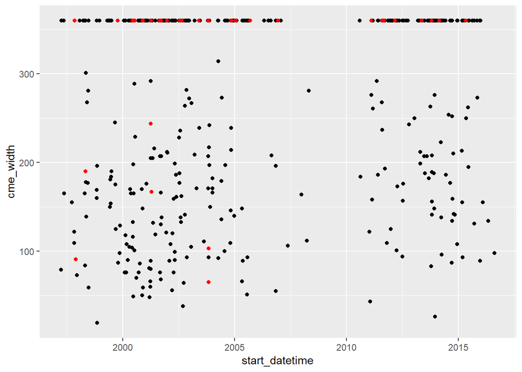

```r
#Flare width over time plot. Top 50 are highlighted in Red
flare_width_plot <- nasa %>% ggplot(mapping=aes(y=cme_width, x= start_datetime), na.rm=TRUE) + geom_point() + geom_point(data = nasa_top50, aes(y = cme_width, x= start_datetime), color = "red")

suppressWarnings(print(flare_width_plot))
```

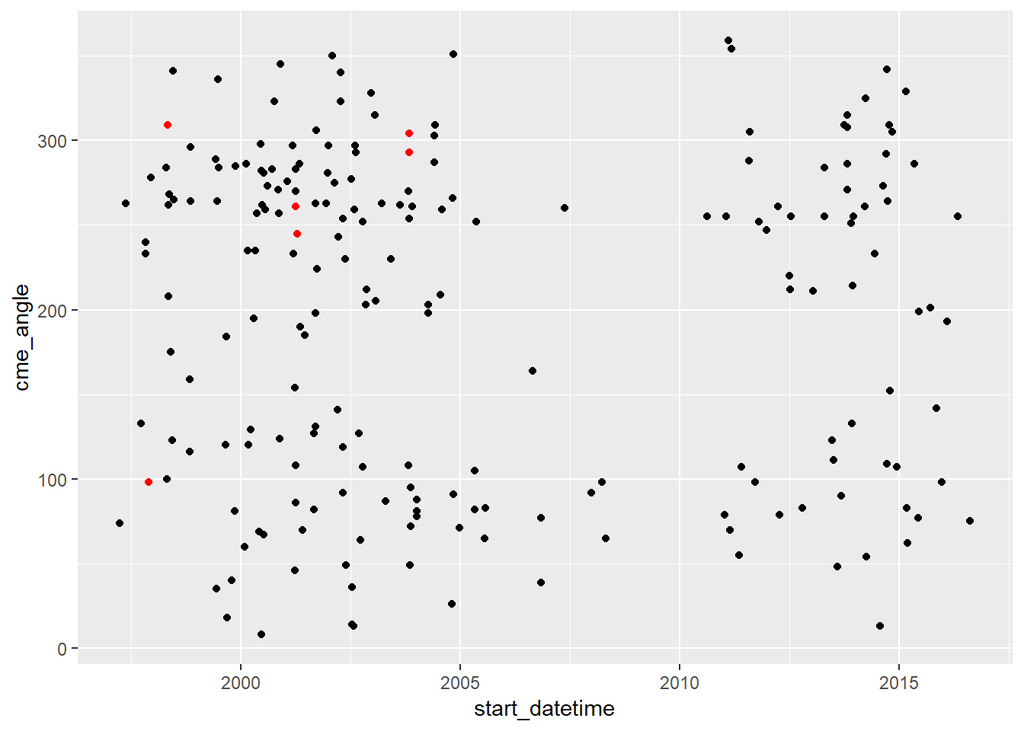

```r
#Flare angle over time plot. Top 50 are highlighted in Red
flare_angle_plot <- nasa %>% ggplot(mapping=aes(y=cme_angle, x= start_datetime), na.rm=TRUE) + geom_point() + geom_point(data = nasa_top50, aes(y = cme_angle, x= start_datetime), color = "red")

suppressWarnings(print(flare_angle_plot))
```

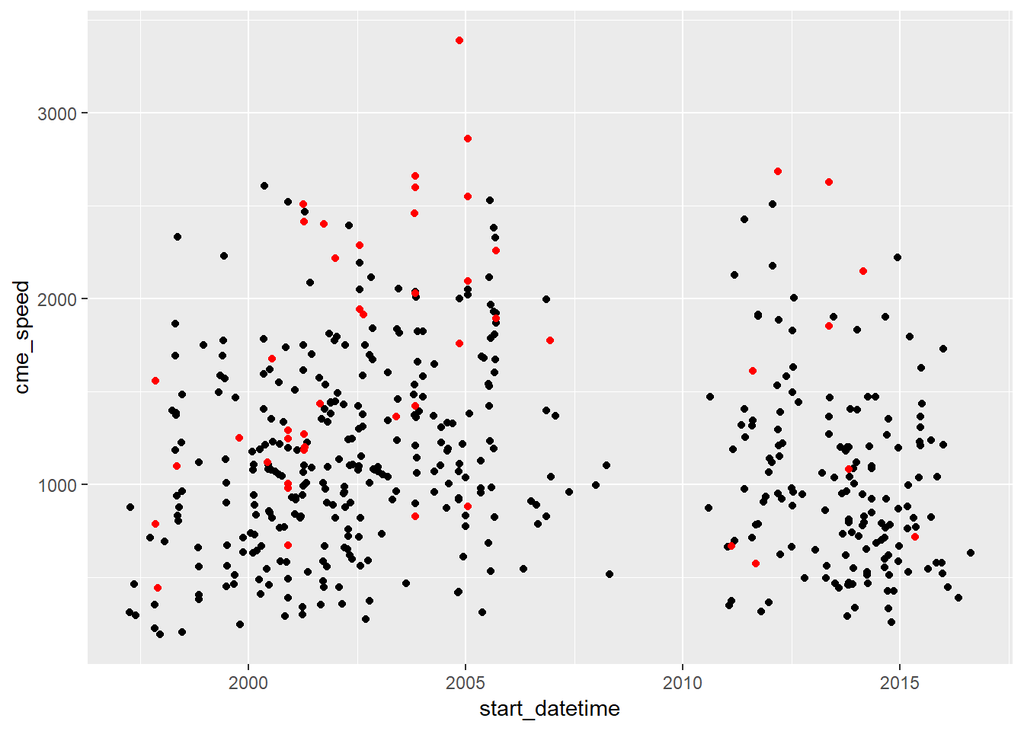

```r
#Flare speed over time plot. Top 50 are highlighted in Red
flare_speed_plot <- nasa %>% ggplot(mapping=aes(y=cme_speed, x= start_datetime), na.rm=TRUE) + geom_point() + geom_point(data = nasa_top50, aes(y = cme_speed, x= start_datetime), color = "red")

suppressWarnings(print(flare_speed_plot))
```

# PART 3 Q2

# The intention of this plot is to show whether or not strong solar flares tend to have halo’s or not. It will show the variation between the proportion of strong solar flares with halos and weaker solar flares with halos

# Description: This plot shows the number of halos that are or are not present in the top 50 solar flares versus those not in the top 50. The portion highlighted in blue are the strong top 50 solar flares while the portion in black is everything else

# Interpretation: According to the plot, one can see that the number of halos and strength of solar flare is correlated. The number of true halo’s in comparison to false in the top 50 has a much higher variation than difference between the weaker solar flare data

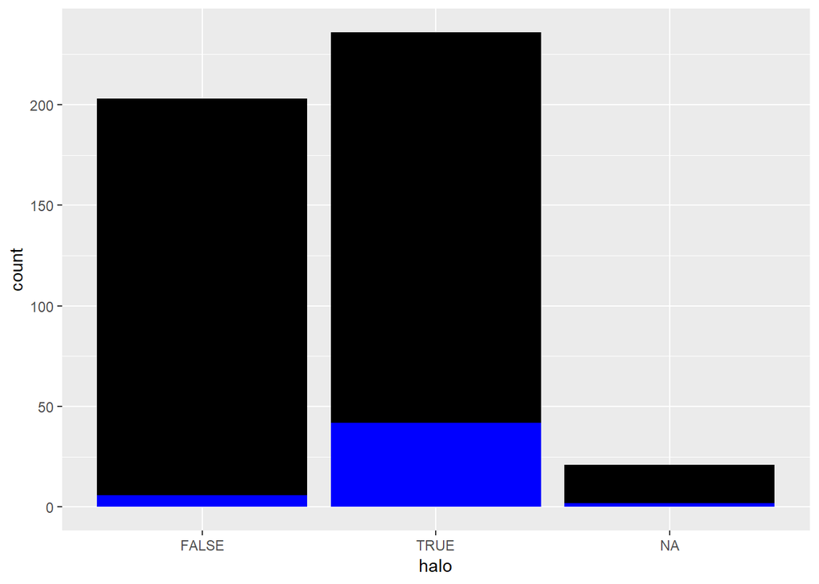

```r
#Create a dataframe without the top50 data
anti_frame <- anti_join(nasa, nasa_top50, by = "flare_classification")

q2_plot <- anti_frame %>% ggplot(mapping=aes(halo), na.rm=TRUE)+geom_bar(fill = "black") + geom_bar(nasa_top50, mapping= aes(halo), fill = "blue")

suppressWarnings(print(q2_plot))
```

# Part 3 Q3

# Intention: The intention of this plot is to show where strong solar flares cluster most

# Description: The first plot shows the number of flares of the whole ataset that are in the flare regions present in the top 50. The second plot groups the number of occurrences a solar flare occurs within a solar region from the top 50 dataset

# Interpretation: Judging by variation in number of flare_regions present in the top 50 plot, it seems as though the top 50 flares are mostly in different regions. However, it seems as though some specific regions are more prone to strong solar flares. Region 9236 has only one flare but in the top 50 it contains the most with five flares. In contrast, it seems as though regions with low amounts of strong flares end up having more weak flares to replace. Flare region 9393 and 8210 had low top 50 flare presence but high weak flare presence

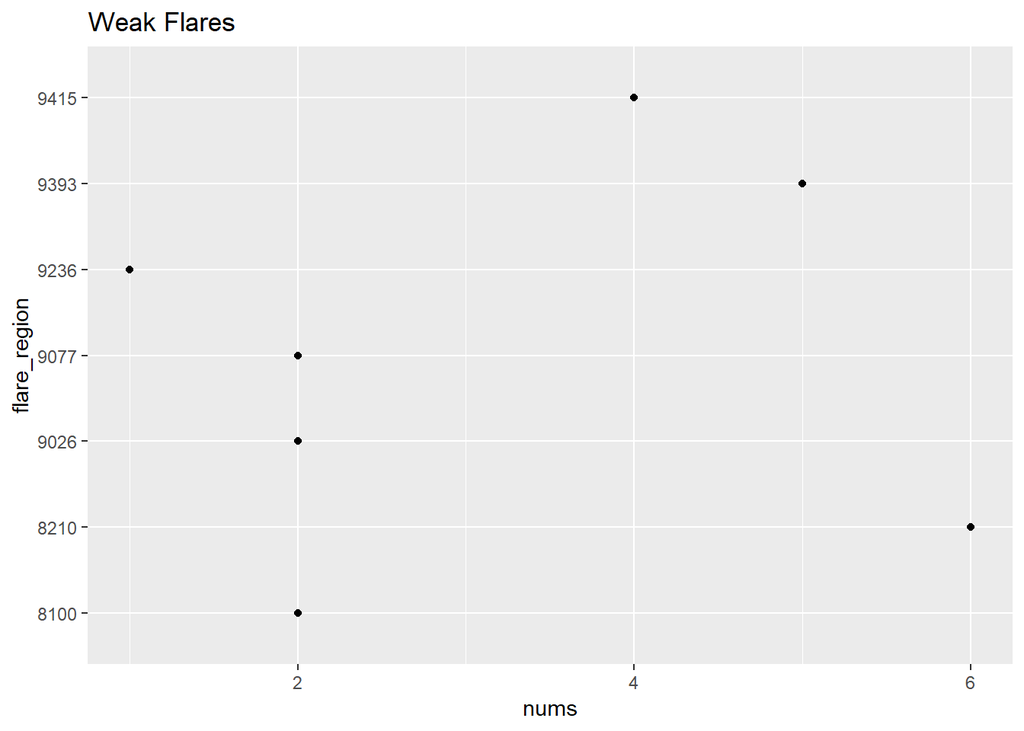

```r
region_reg_plot <- anti_frame %>% filter(flare_region %in% nasa_top50$flare_region) %>% group_by(flare_region) %>% summarize(nums = n()) %>% ggplot(mapping=aes(y=flare_region, x=nums)) + geom_point() + ggtitle("Weak Flares")

suppressWarnings(print(region_reg_plot))
```

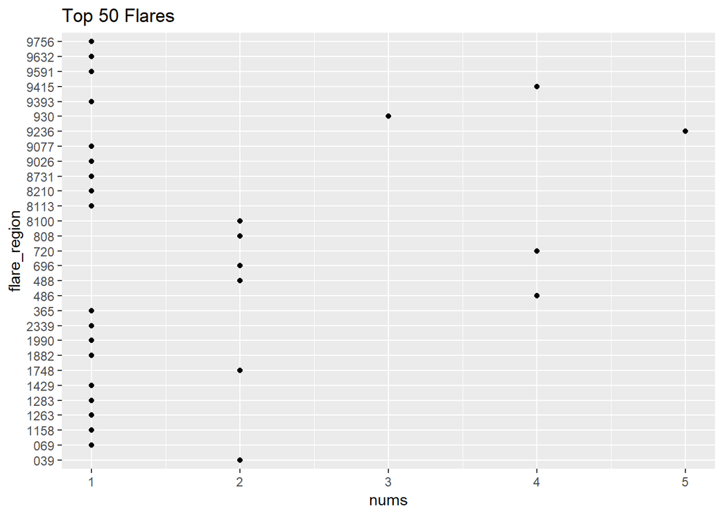

```r
region_top50_plot <- nasa_top50 %>% group_by(flare_region) %>% summarize(nums = n()) %>% ggplot(mapping=aes(y=flare_region, x=nums)) + geom_point() + ggtitle("Top 50 Flares")

suppressWarnings(print(region_top50_plot))
```